# Lab 13: Working with Categorical Data

## Instructions

Below you will find several empty R code scripts. Your task is to fill in the required code snippets.

## Arbuthnot Births Dataset

Today we will be working with the Arbuthnot births dataset from the second week of the semester (I kept this assignment short so that you can move onto the project with the remaining time):

## Making Numbers Categorical

Start by creating a scatter plot with year on the x-axis and total number of births on the y-axis. Color the points based on the number of girls that were born in the that year:

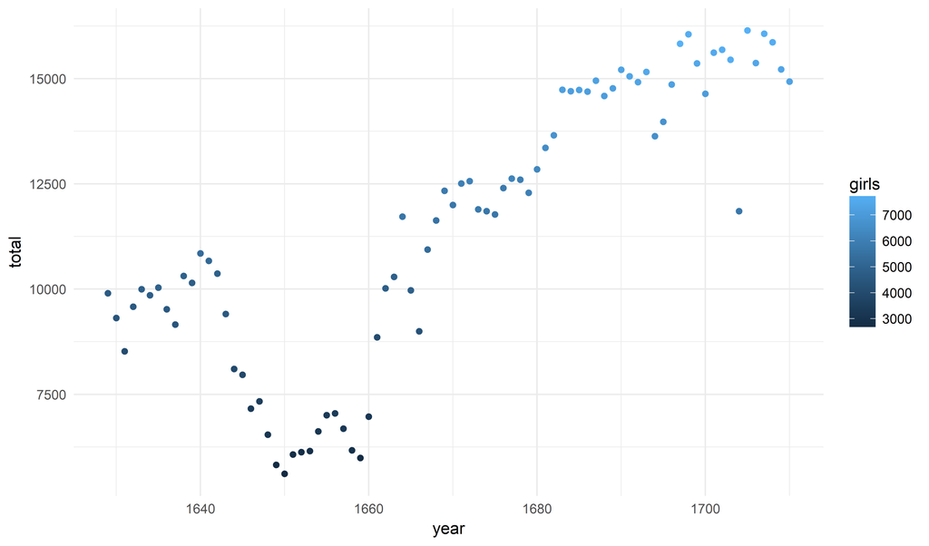

Now, convert `girls` to a factor using the `factor()` function. Notice how the colors change:

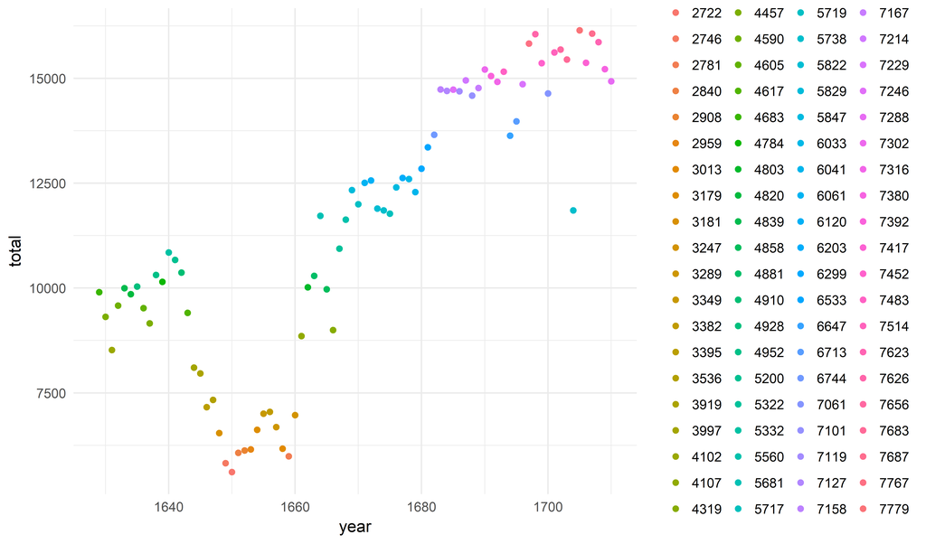

Try instead to use the `bin` command to bin the girls variable:

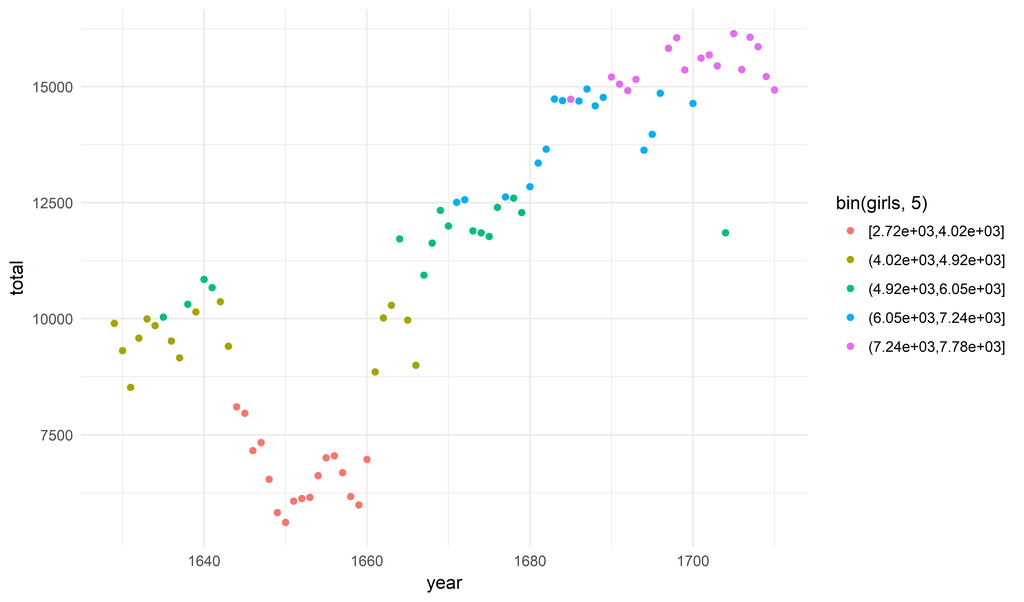

Think about the differences between these three plots: numeric number of girls, factor number of girls, and binned number of girls.

## Reordering Factors

Now, create a line plot with year on the x-axis and the total number of births on the y-axis. Color the lines based on the head of state:

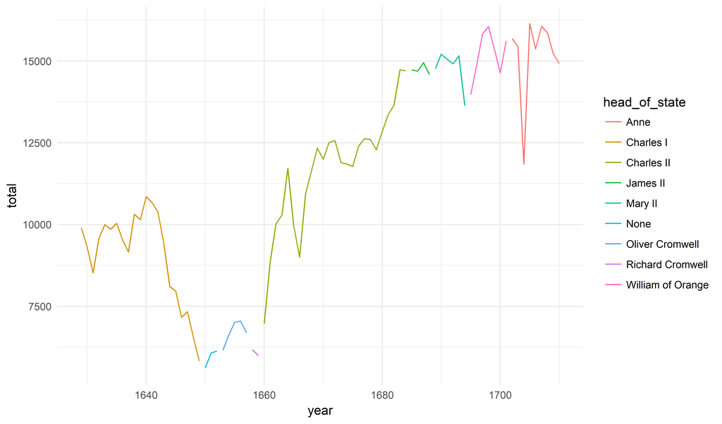

Now using `fct_inorder` to convert the ordering of the heads of state:

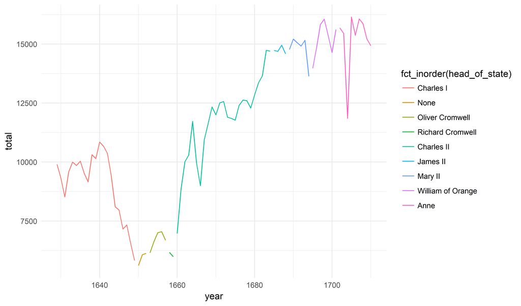

Notice that this is a better way to present the data (and something we wanted to do back in week 2 but did not yet know how to do it).